# Assignment 2

PCA and Principal Curves

Alexander, Ulrik, Hannes

07/Mar/2022

# 1 PCA and Principal Curves for ZIP numbers

Consider the ZIP data set. Read the train data set and select only the zeros.

```r
zip.train <- read.table("../unsup/zip.train")
dim(zip.train)
```

```
#> [1] 7291  257
```

```r
table(zip.train[,"V1"])
```

```
#>
#>    0    1    2    3    4    5    6    7    8    9
#> 1194 1005  731  658  652  556  664  645  542  644
```

```r
zip.zeros <- zip.train %>% dplyr::filter(V1 == 0)
dim(zip.zeros)
```

```
#> [1] 1194  257
```

## 1.1 Questions

### 1.1.1 Hierarchical Clustering

Hierarchical clustering using the **ward.D** method. The dendrogram is plotted below and it is cut into $k = 4$ clusters.

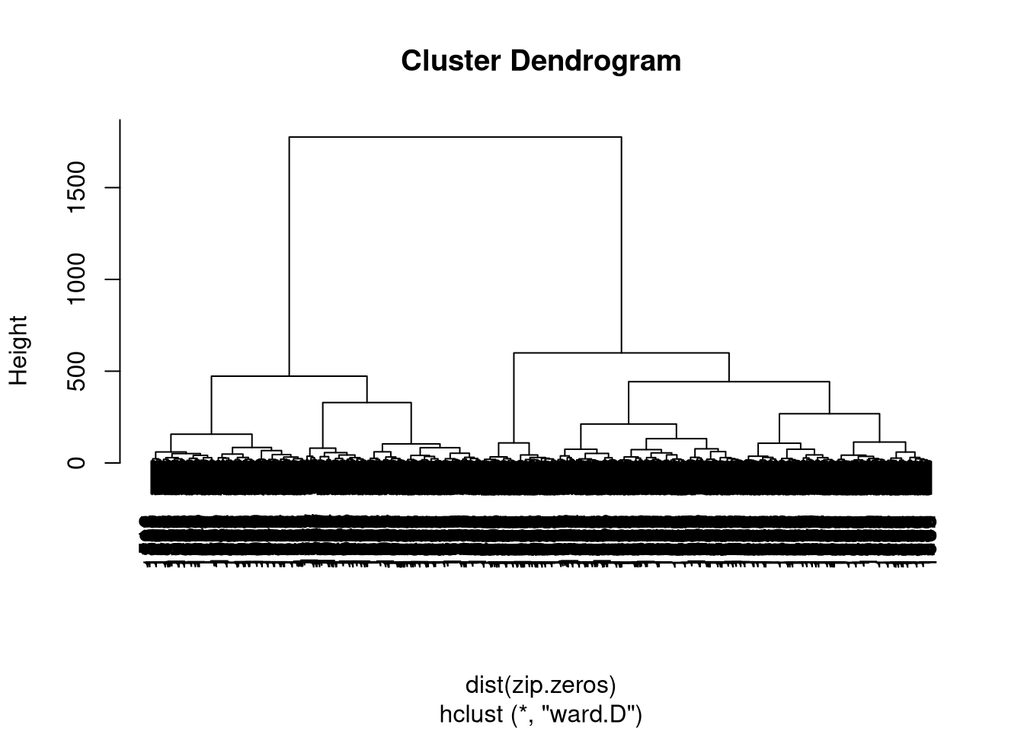

```r
hcl1 <- hclust(dist(zip.zeros), method="ward.D") # Euclidean distance, ward.D method.
plot(hcl1)
```

```r
clusts <- cutree(hcl1, 4)
table(clusts)
```

```
#> clusts
#>   1   2   3   4
#> 236 574 115 269
```

```r
zip.zeros$cluster <- clusts # Add the cluster of each point to a new column.
```

The table above shows how the zeros are distributed across the clusters.

### 1.1.2 Average Digit at Each Cluster

The average digit in each cluster is plotted.

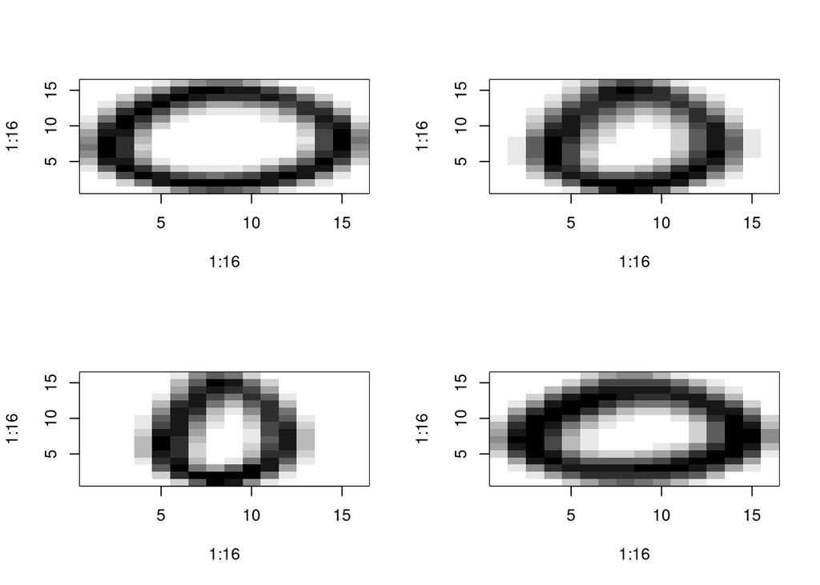

```r
# Function for plotting a digit. Taken from "PCA_ZIP_numbers.Rmd" (lectures).
plot.zip <- function(x,use.first=FALSE){
  x<-as.numeric(x)
  if (use.first){
    x.mat <- matrix(x,16,16)
  }else{
    x.mat <- matrix(x[-1],16,16)
  }
  image(1:16,1:16,x.mat[,16:1],
        col=gray(seq(1,0,l=12)))
  if (!use.first) title(x[1])
}

# Calculate the average digit in each cluster.
# This could be probably be done more efficiently
average.images <- zip.zeros[1:4,-1]
for (i in 1:4){
   for (j in 1:256){
      average.images[i,j] <- mean((zip.zeros %>% dplyr::filter(cluster == i))[,j+1])
   }
   average.images[i,257] <- i
}

op <- par(mfrow=c(2,2))
apply(average.images[,-ncol(average.images)],1, plot.zip, use.first = T)
```

### 1.1.3 Principal Components

The principal components for this data set are calculated. The scatterplot of the scores in the two first components are plotted, using different colors for points in different clusters.

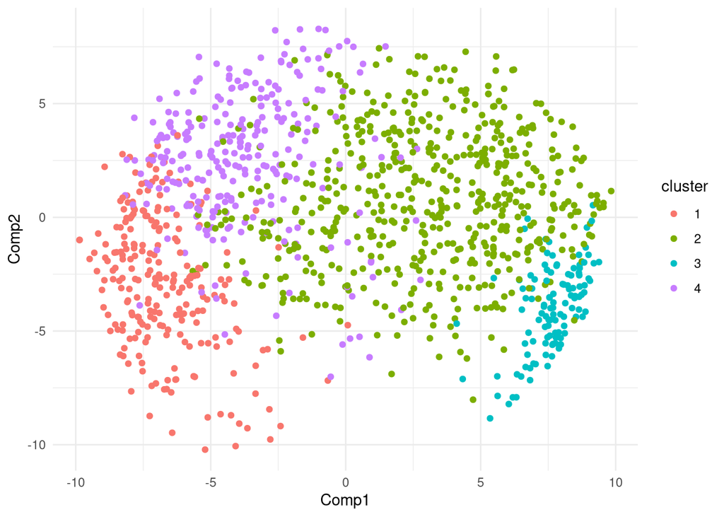

```r
zip.PC <- princomp(zip.zeros[,-c(1,ncol(zip.zeros))])
df <- data.frame(Comp1 = zip.PC$scores[,1], Comp2 = zip.PC$scores[,2], cluster = factor(zip.zeros$cluster))
df %>% ggplot(aes(x = Comp1, y = Comp2)) +
   geom_point(aes(color = cluster)) +
   theme_minimal()
```

### 1.1.4 For each of the $k = 4$ Clusters, do …

#### 1.1.4.1 Consider the bivariate data set of the scores PC1 and PC2 of the points in the cluster

```r
df.clust1 <- df %>% dplyr::filter(cluster == 1)
df.clust2 <- df %>% dplyr::filter(cluster == 2)
df.clust3 <- df %>% dplyr::filter(cluster == 3)
df.clust4 <- df %>% dplyr::filter(cluster == 4)
```

#### 1.1.4.2 Estimate non-parametrically the joint density of (PC1, PC2) conditional to the cluster, using the default bandwidth values. Represent the estimated bivariate density via the 75% level curve

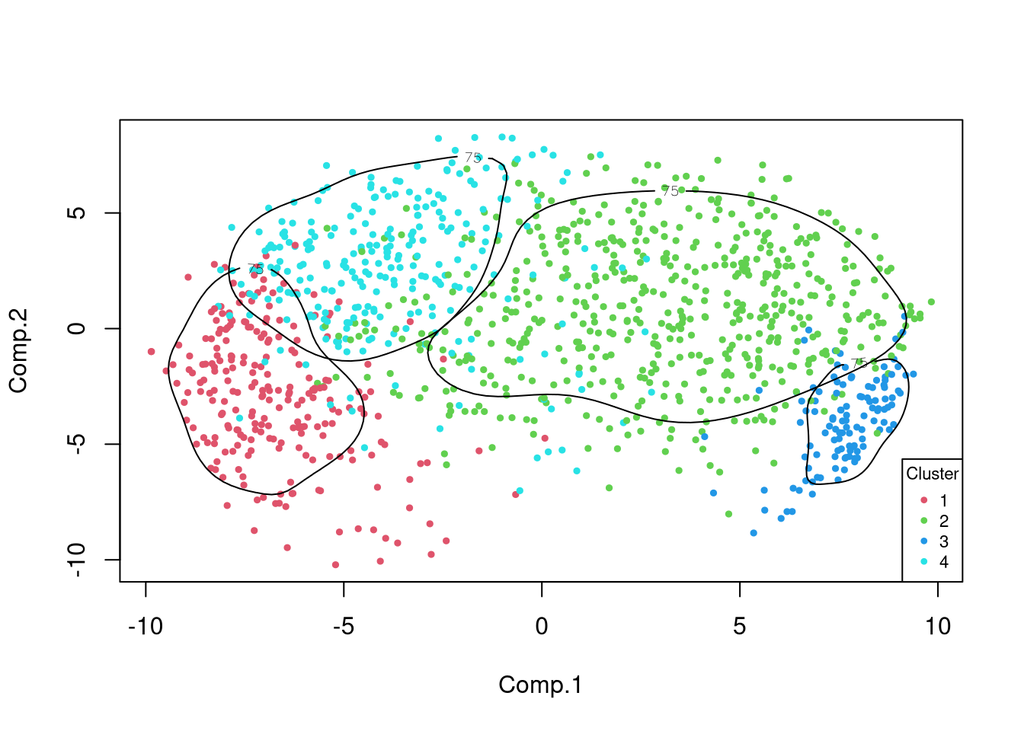

```r
plot(zip.PC$scores[,1:2],pch=19,cex=.5,col=zip.zeros[,ncol(zip.zeros)]+1)
sm.density(df.clust1[, c(1,2)], display="slice",props=c(75), add = T)
sm.density(df.clust2[, c(1,2)], display="slice",props=c(75), add = T)
sm.density(df.clust3[, c(1,2)], display="slice",props=c(75), add = T)
sm.density(df.clust4[, c(1,2)], display="slice",props=c(75), add = T)
legend(x = "bottomright", legend = c("1","2","3","4"), title = "Cluster",
       col=c(2,3,4,5), pch = 20, cex = 0.7)
```

### 1.1.5 Principal Curve

The principal curve obtained from the 256-dimensional set of zeros will be represented in the previous plot, using the package **princurve**. The principal curve is plotted as a dotted line below.

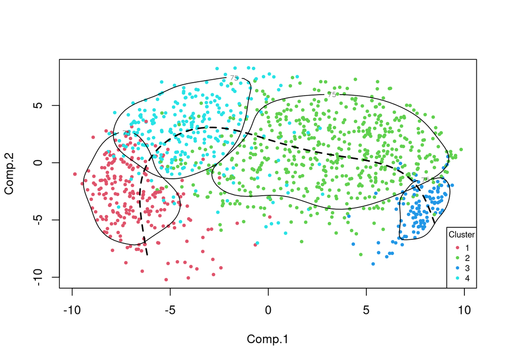

```r
plot(zip.PC$scores[,1:2],pch=19,cex=.5,col=zip.zeros[,ncol(zip.zeros)]+1)
sm.density(df.clust1[, c(1,2)], display="slice",props=c(75), add = T)
sm.density(df.clust2[, c(1,2)], display="slice",props=c(75), add = T)
sm.density(df.clust3[, c(1,2)], display="slice",props=c(75), add = T)
sm.density(df.clust4[, c(1,2)], display="slice",props=c(75), add = T)
legend(x = "bottomright", legend = c("1","2","3","4"), title = "Cluster",
       col=c(2,3,4,5), pch = 20, cex = 0.7)
princ.curve <- principal_curve(as.matrix(zip.zeros[,-c(1,ncol(zip.zeros))]))
# Projecting the principal curve over the Principal Components
proj.prcv.to.PC <- predict(zip.PC,princ.curve$s)
lines(proj.prcv.to.PC[princ.curve$ord,1:2],col=1, lty = 2, lwd=2)
```

### 1.1.6 For each of the $k = 4$ Clusters, do …

#### 1.1.6.1 Consider the univariate data set of the ‘lambda’ scores over the principal curve of the points in this cluster.

```r
# Make a new data set with lambda and clusters.
df2 <- data.frame(lambda = princ.curve$lambda, cluster = factor(zip.zeros$cluster))

# Make new data frames (from the above) for each cluster.
df2.clust1 <- df2 %>% dplyr::filter(cluster == 1)
df2.clust2 <- df2 %>% dplyr::filter(cluster == 2)
df2.clust3 <- df2 %>% dplyr::filter(cluster == 3)
df2.clust4 <- df2 %>% dplyr::filter(cluster == 4)
```

#### 1.1.6.2 Estimate non-parametrically the density function of lambda, conditional to this cluster. Use the default bandwith value. Plot the estimated density function.

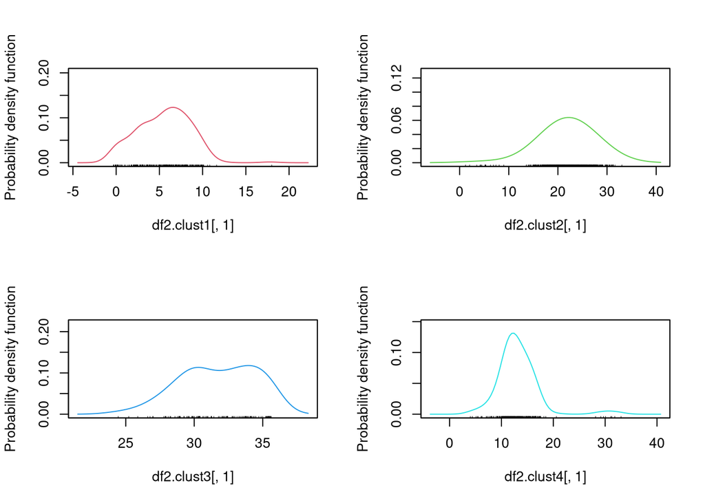

```r
op <- par(mfrow=c(2,2))
sm.density(df2.clust1[, 1], add = F, col = "2")
sm.density(df2.clust2[, 1], add = F, col = "3")
sm.density(df2.clust3[, 1], add = F, col = "4")
sm.density(df2.clust4[, 1], add = F, col = "5")
```

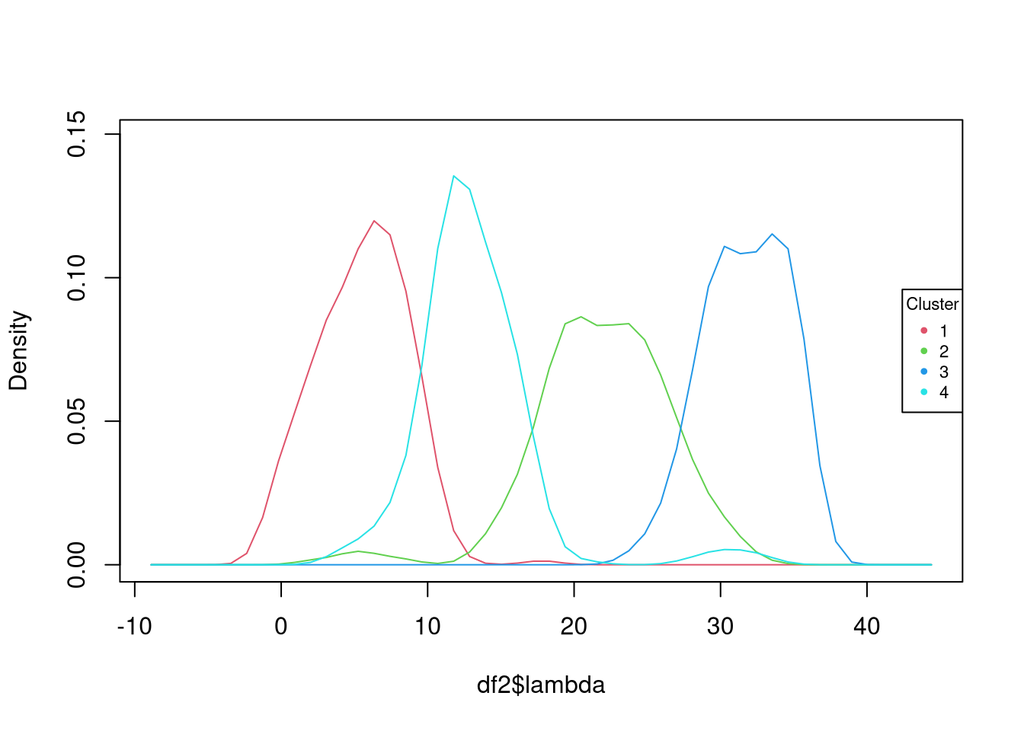

```r
par(mfrow=c(1,1))
sm.density.compare(x = df2$lambda, group = df2$cluster, col = c(2,3,4,5),
                   lty=c(1,1,1,1))
legend(x = "right", legend = c("1","2","3","4"), title = "Cluster",
       col=c(2,3,4,5), pch = 20, cex = 0.7)
```

Above the non-parametric density estimation of lambda in each cluster is plotted by itself, and then together using the **sm.density.compare()** function. In the problem description it sounds like this should be plotted over the principal component plot above, but we do not understand how this could be done.

The density plots shows that in cluster 1 lambdas are lowest, followed by cluster 4, cluster 2, and finally cluster 3. This matches with previous plots of the principal curve which clearly goes through the clusters in this order. Looking at the average zero plot in each group, we observe that the zeros in cluster 1 and 4 are similar (wide). In cluster 2 the zeros are smaller and narrower, and in cluster 3 they are the smallest. It looks like the principal curve moves from large and wide zeros, to smaller and narrow ones.

# 2 Choosing the smoothing parameter in Principal Curves (Hastie and Stuetzle 1989)

Consider the 3-dimensional data generated from the following code.

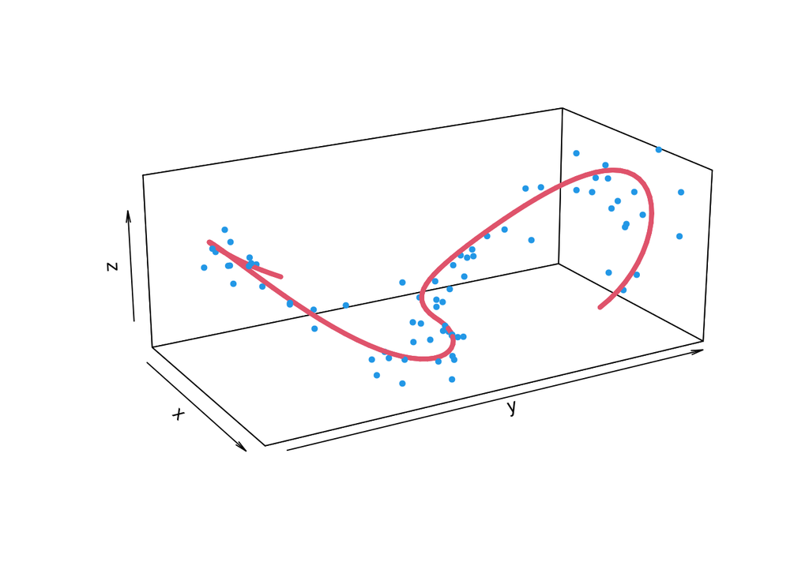

```r
t <- seq(-1.5*pi,1.5*pi,l=100)
R<- 1
n<-75
sd.eps <- .15
set.seed(1)

y <-  R*sign(t) - R*sign(t)*cos(t/R)
x <- -R*sin(t/R)
z <- (y/(2*R))^2
rt <- sort(runif(n)*3*pi - 1.5*pi)
eps <- rnorm(n)*sd.eps
ry <- R*sign(rt) - (R+eps)*sign(rt)*cos(rt/R)
rx <- -(R+eps)*sin(rt/R)
rz <- (ry/(2*R))^2 + runif(n,min=-2*sd.eps,max=2*sd.eps)
XYZ <- cbind(rx,ry,rz)
require(plot3D)
lines3D(x,y,z,colvar = NULL,
phi = 20, theta = 60, r =sqrt(3), d =3, scale=FALSE,
col=2,lwd=4,as=1,
xlim=range(rx),ylim=range(ry),zlim=range(rz))
points3D(rx,ry,rz,col=4,pch=19,cex=.6,add=TRUE)
```

## 2.1 Questions

### 2.1.1 Choose the Value of the Degrees of Freedom by Leave-One-Out Cross-Validation (LOOCV)

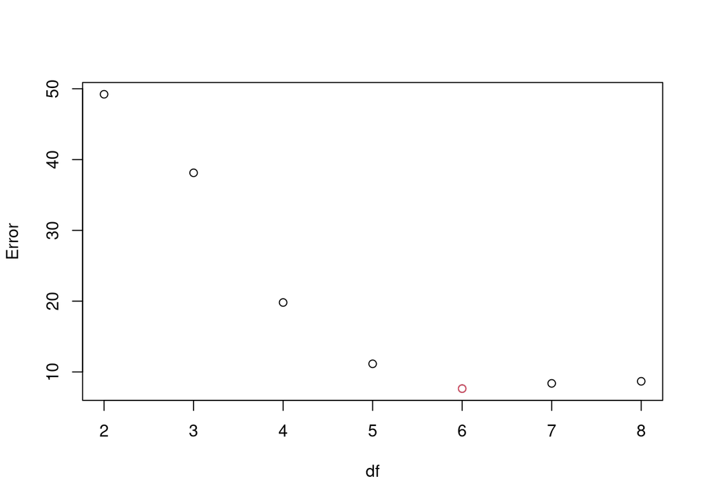

```r
dfValues <- seq(2,8,by=1)
errVect <- matrix(0, nrow=1, ncol=7)

for (dfValue in dfValues){
  i = dfValue
  err <- 0
  for (p in (1:dim(XYZ)[1])){

    train_set <- XYZ[-p,]

    test_set <- t(as.matrix(XYZ[p,]))
    prin <- principal_curve(train_set, df = i)
    proj <- project_to_curve(test_set,prin$s)
    err <- err + proj$dist
    }
  errVect[i-1] <- err
}
plot(dfValues, errVect,xlab="df", ylab="Error")
opt.ind <- which.min(errVect)
objective.opt <- errVect[opt.ind]
df.opt <- dfValues[opt.ind]
points(dfValues[opt.ind],errVect[opt.ind], col = 2)
```

Above the distances are plotted as a function of the df-value. From the plot we can see that the optimal value for df (of the seven tested ones) were df = 6 which corresponded to a value of 7.646.

### 2.1.2 Give a graphical representation of the principal curve output for the optimal df and comment on the obtained results.

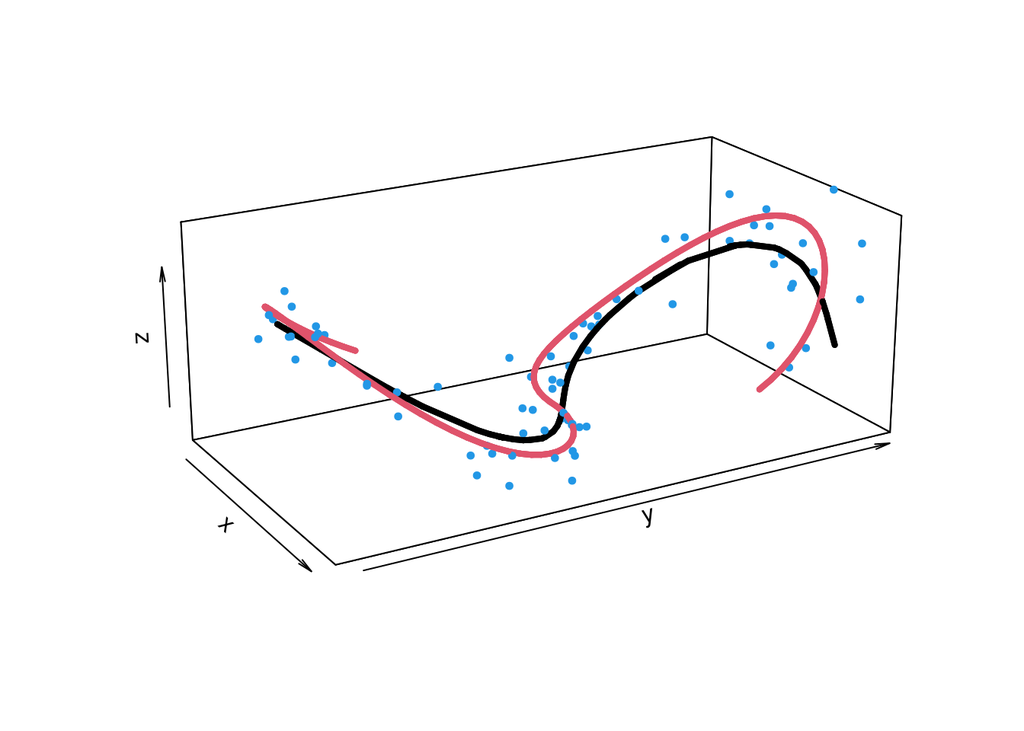

```r
fit.df.opt <- principal_curve(XYZ, df = df.opt)
lines3D(x,y,z,colvar = NULL,
phi = 20, theta = 60, r =sqrt(3), d =3, scale=FALSE,
col=2,lwd=4,as=1,
xlim=range(rx),ylim=range(ry),zlim=range(rz))
lines3D(fit.df.opt$s[,1],fit.df.opt$s[,2],fit.df.opt$s[,3],colvar = NULL,
phi = 20, theta = 60, r =sqrt(3), d =3, scale=FALSE,
col=1,lwd=4,as=1,
xlim=range(rx),ylim=range(ry),zlim=range(rz), add = TRUE)
points3D(rx,ry,rz,col=4,pch=19,cex=.6,add=TRUE)
```

The plot above shows the principal curve in black, fitted with 6 degrees of freedom chosen by the LOOCV. It seems reasonably close to the generator curve in red, and captures the bent “S”-shape. It deviates more in at the ends where there are fewer data points in the “neighborhood”.

### 2.1.3 Compute the leave-one-out cross-validation for df=50 and compare it with the result corresponding to the optimal df value you found before.

```r
i=50
errDf50 <- 0
for (p in (1:dim(XYZ)[1])){
  train_set <- XYZ[-p,]
  test_set <- t(as.matrix(XYZ[p,]))
  prin <- principal_curve(train_set, df = i)
  proj <- project_to_curve(test_set,prin$s)
  errDf50 <- errDf50 + proj$dist
}
cat("The calculated error corresponding to df = 50 was ", errDf50, ".")
```

```
#> The calculated error corresponding to df = 50 was  2.956499 .
```

The previous error we found with df = 6 was 7.646. Now, with df = 50, we get the significantly lower error 2.956. Thus, the average distance from the points to the curve fitted without including the points is lower, which in general is good. However, fitting a curve with 50 degrees of freedom from only 75 data points immediately sounds prone to overfitting and in general bad practice. We plot the principal curve with df = 50 to see why this can happen.

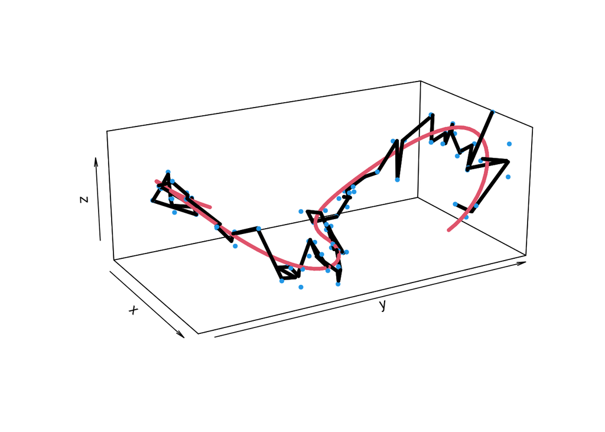

```r
fit.df.opt <- principal_curve(XYZ, df = 50)
lines3D(x,y,z,colvar = NULL,
phi = 20, theta = 60, r =sqrt(3), d =3, scale=FALSE,
col=2,lwd=4,as=1,
xlim=range(rx),ylim=range(ry),zlim=range(rz))
lines3D(fit.df.opt$s[,1],fit.df.opt$s[,2],fit.df.opt$s[,3],colvar = NULL,
phi = 20, theta = 60, r =sqrt(3), d =3, scale=FALSE,
col=1,lwd=4,as=1,
xlim=range(rx),ylim=range(ry),zlim=range(rz), add = TRUE)
points3D(rx,ry,rz,col=4,pch=19,cex=.6,add=TRUE)
```

As expected the principal curve overfits, and is very jagged and non-smooth. The LOOCV error is better in this case than the preferred fit with df = 6. This happens because we measure the error as the distance from the point to its projection on the curve, which does not necessarily increase when we overfit. In the extreme case where df goes to infinity, the principal curve can “fill” the space, and every random point in the space will be infinitely close to its projection.